# CRIM 595 CITY OF FAIRFAX HOTSPOTS PROJECT

HU

2023-06-23

*STEPS TO SUCCESS*

##### UNLOAD PACKAGES

```
## in your R script or .Rprofile.
```

##### STEP 1: RETRIEVE CITY OF FAIRFAX CALLS FOR SERVICE GEOGRAPHIC DATA

##### STEP 2: CLEAN DATA, FORMAT DATE AND TIME

```r
calls.temp$date <- as.Date(calls.temp$date)
calls.temp$dow <- weekdays(calls.temp$date)
calls.temp$month <- substr(calls.temp$date, 6, 7)
calls.full <- subset(calls.temp, !is.na(calls.temp$lat))
```

##### STEP 3: CALCULATE AND DETERMINE COMMON CALL ACTIVITY

```r
calls.year <- calls.full %>%
  group_by(year) %>%
  summarise(count = n()) %>%
  mutate(PCT = round(count/sum(count)*100,2))

calls.type <- calls.full %>%
  group_by(type) %>%
  summarise(count = n()) %>%
  mutate(PCT = round(count/sum(count)*100,2))

calls.type <- calls.type[order(-calls.type$count),] # sort in descending order by count
diffs <- diff(calls.type$PCT)
diffs <- c(0, diffs)
calls.type$diff <- diffs
```

##### STEP 4: SUBSET THE DATA, IDENTIFY CALL TYPE AND FILTER

```r
calls <- subset(calls.full, calls.full$type == 'MENTAL')
```

##### STEP 5: VISUALIZE THE HOTSPOTS AND COLDSPOTS OF THE DATA WITH DENSITIES ACROSS TIME AND OVER TIME

###### HOUR OF DAY (ACROSS TIME)

Between the hours 9:00pm and 12:00am the volume of mental health calls appear to be more concentrated in the Downtown area of the city of Fairfax — which includes George Mason Boulevard, University Drive, Chain Bridge Road, Main Street, Armstrong Street, and Courthouse Drive,and the Police Department (Blenheim Road). Throughout the remaining hours of the day, mental health calls are not as intense, but seem to remain common within the Downtown and Police Department area, although between 10:00am and 11:00pm the concentration of calls increase in the Northeast corner of the city — which includes Fairfax Boulevard, Arlington Boulevard, Old Pickett Road, and Blenheim Road. In contrast, the North and Northwest areas of the city — which includes Atlanta Street, Blue Coat Drive, Flintlock Road, Jermantown Road, Rock Garden Drive, Plantation Parkway, Bevan Drive, and Orchard Street, have little to no concentration of mental health call activity.

*PREDICTION*: Unless there are profound internal and/or external interventions that influence the city of Fairfax in the near future, the Downtown area will likely have the most concentration of mental health calls. Mental health calls are also likely to occur in the evening and later hours of the day, due to factors such as work schedules (and the likely consequent feelings of isolation or hopelessness that may persist when work or productiveness is not occupied), operating business hours of certain establishments (i.e. bars), or perceptions that officers are handing “more important” calls during the day.

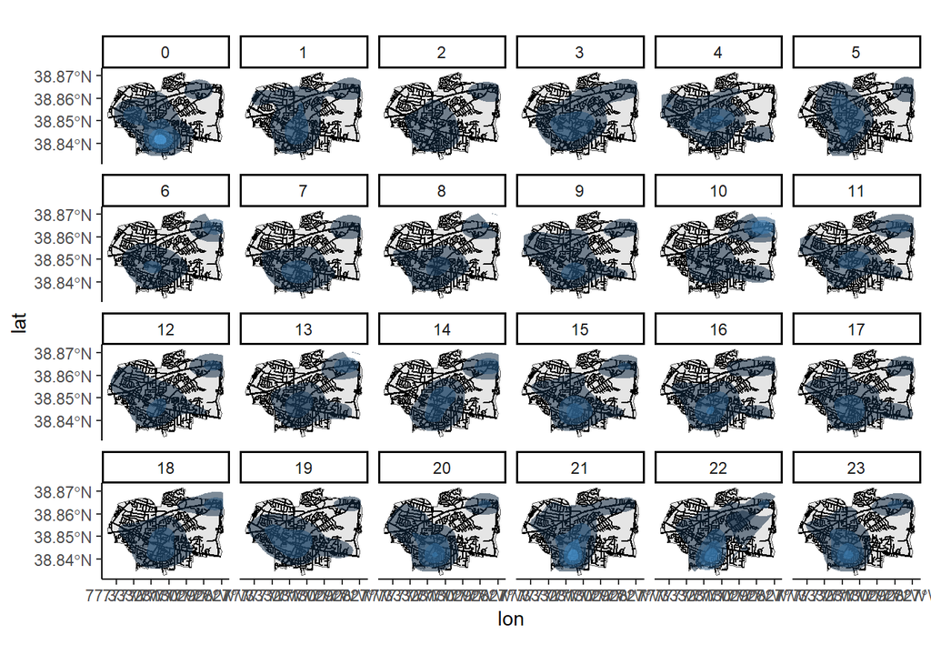

###### DAY OF WEEK (ACROSS TIME)

During Wednesday, Thursday, and Friday, there is a higher concentration of mental health call activity in the Downtown area of the city of Fairfax, the Police Department, and Northeast corner of the city. There also appears to be a progression from the beginning of the week (Sunday until Tuesday), and a slight decrease of call activity on Saturday in comparison to Wednesday through Friday call volumes. It is interesting however, that on any given day there is still a considerable volume of mental call activity. In contrast, the North and Northwest areas of the city have little to no mental health call activity consistent throughout the week.

*PREDICTION*: work-life balance may be a contributing factor to the “progression” trend that seems to have occurred throughout the week, as well as traffic/commute in these concentrated areas and socioeconomic factors. This trend will likely remain consistent unless there be any infrastructural needs or demands being met or efflux of certain conditions and factors in the near future.

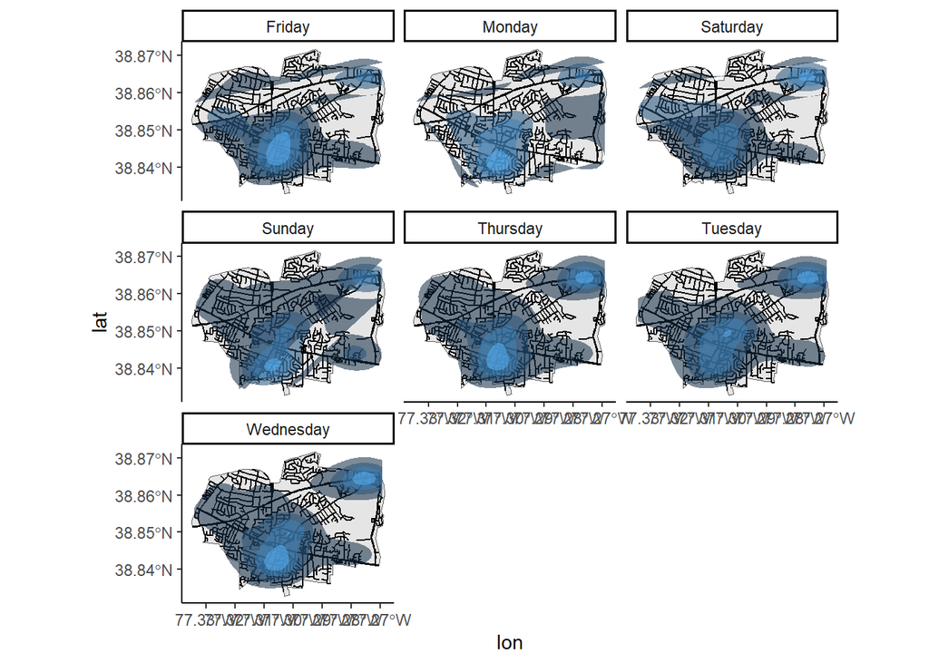

###### MONTH OF YEAR (ACROSS TIME)

The months of February, September, November, and December have higher concentrations of mental health call activity in the Downtown area of the city of Fairfax and the Police Department, and July and August have higher concentrations of mental health calls in The Northeast corner of the city. it is interesting to note that although there does not appear to be a seasonal trend per se when it comes to typical weather changes during the months of a year, the months in the second half of the year have more concentration of mental health call activity. Also, during Mental Health Awareness Month, which is observed in May, there is a shift and seeming decrease of mental health call volumes. In contrast, the North and Northwest areas of the city have consistent little to no mental health call activity.

*PREDICTION*: It is likely that the hotspots and coldspots during the months of the year will stay consistent, unless there are any profound internal and/or external interventions that influence the city of Fairfax made on a hourly and daily basis.

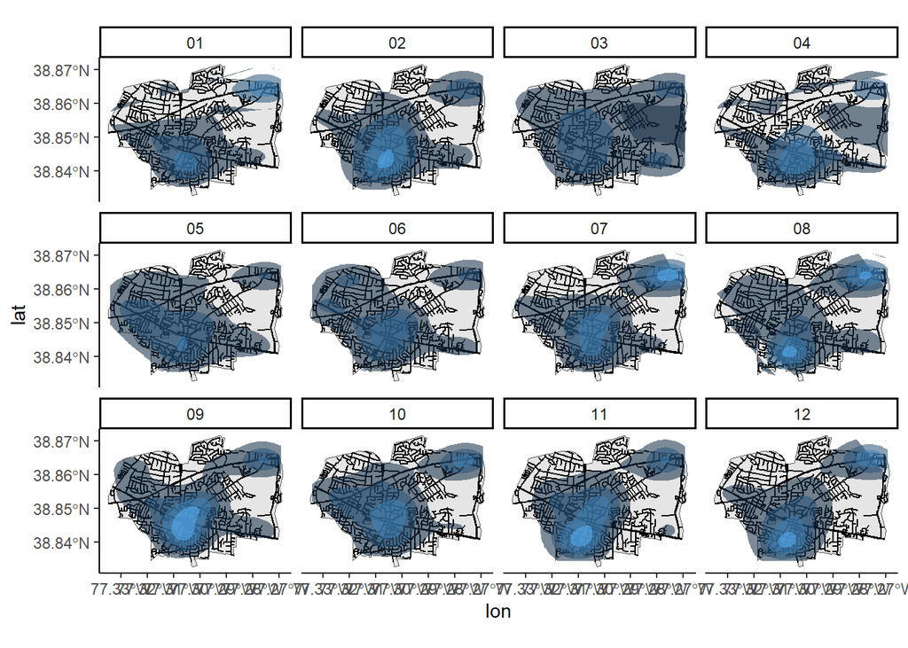

###### BONUS: YEAR BY YEAR (OVER TIME)

Patterns that occur across time can gradually occur over time if trends remain constant on an hourly, daily, and monthly basis. Hotspots in 2014 stand out significantly, which can be attributed to the socioeconomic and political turmoil that had either shifted or been sustained from prior years. In the collective years from 2007-2023 thus far, there has not appeared to be a considerable amount of mental health call volumes, but that may be based on whether calls are being reported as a mental health call, or whether a mental health call is being made at all, based primarily on perceived lack of trust and hope in policing — a reason why predictive policing and environmental criminology should be explored more in intersecting communities.

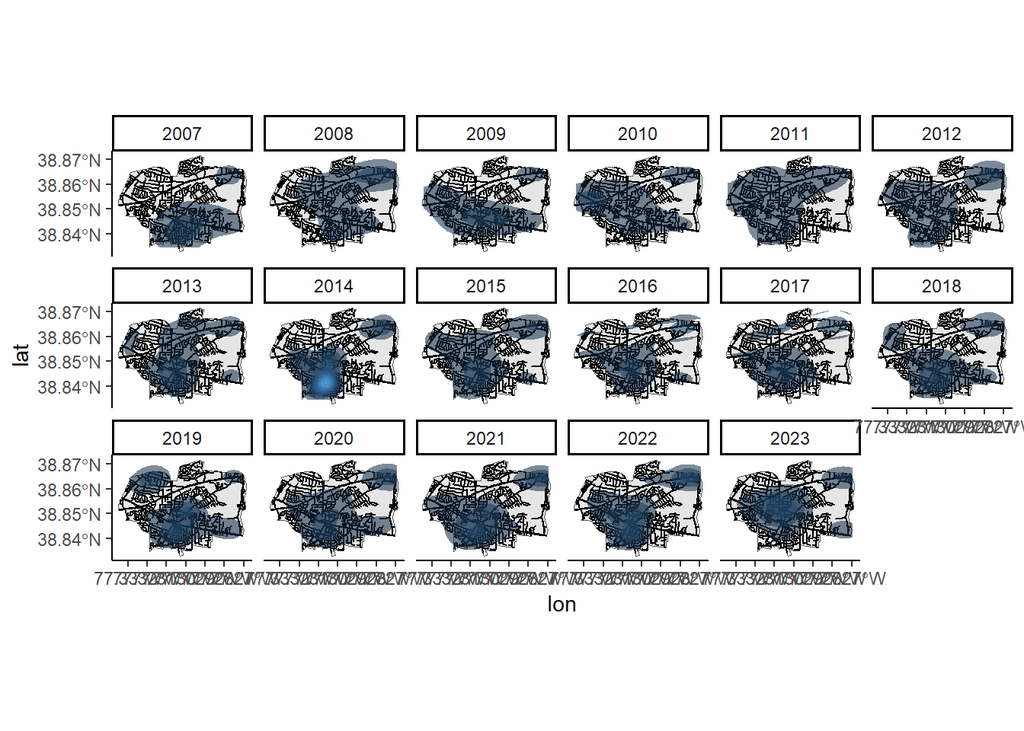

###### EXTRA BONUS: LEAFLET INTERACTIVE MAP OF THE CITY OF FAIRFAX, VIRGINIA

```r
leaflet(calls) %>%
   addProviderTiles("CartoDB.DarkMatter") %>%
  addMarkers(lng = ~lon, lat = ~lat,
             popup = paste(
               "Call Type: ", calls$type, "<br>",
               "Date:", calls$date),
             clusterOptions = markerClusterOptions()) %>%
  addPolygons(data = fairfax.city)
```

[interactive chart not shown]

##### CLOSING REMARKS

With the recent launching and implementation of the 988 Mental Health Crisis Hotline across the United States, named after Marcus-David Peters — a young, Black biology teacher, killed by Richmond police in 2018 amid a mental health crisis, it is both timely and essential to identify the ‘where’ and ‘when’ patterns of mental health calls in the city of Fairfax, Virginia, even extending to outside agencies or regional requests. Analyses of spatial crime forecasting and predicting for mental health calls could help to reduce the criminalization of mental health conditions by identifying and mining sequential pattern and data within time and space, and strategically implementing services within areas where the volume of mental health calls are clustered in hotspots, or even detect deviations of where they may be outliered in coldspots. As the remaining cities and counties in Virginia begin to use the Marcus 988 alert system, predictive policing in conjunction could support early intervention efforts and in prospect, reallocate resources into the establishment of 988 Mental Health Crisis facilities, in which co-responder teams can further support the mental health community — beyond the hour of day, the day of week, the month of year, and even year by year projections.